# *mgd* genotyping primers + CRISPR guide in maize LH244

Whole-genome e-PCR specificity → overlap with gene annotation → gggenomes annotation maps

Author

thegemmalab@ncsu.edu

Published

July 29, 2026

```r
suppressPackageStartupMessages({
  library(gggenomes); library(ggplot2); library(readr)
  library(dplyr); library(tidyr); library(stringr); library(Biostrings)
})

# Relative paths — Quarto executes chunks from the project root (portable).
DATA <- "data"; WORK <- "work_lh244"; RES <- "results_lh244"
for (d in c(DATA, WORK, RES)) dir.create(d, showWarnings = FALSE, recursive = TRUE)

BASE   <- "https://download.maizegdb.org/Zm-LH244-REFERENCE-CAU-1.0"
GENOME <- file.path(DATA, "Zm-LH244-REFERENCE-CAU-1.0.fa.gz")   # bgzip, as distributed
GENOFA <- file.path(DATA, "LH244.fa")                            # plain FASTA for e-PCR / BLAST
GFFGZ  <- file.path(DATA, "Zm-LH244-REFERENCE-CAU-1.0_Zm00116aa.1.gff3.gz")
GFF    <- file.path(WORK, "LH244.gff3")
TEGZ   <- file.path(DATA, "Zm-LH244-REFERENCE-CAU-1.0.fa.TE.gff3.gz")   # RepeatMasker track
TEGFF  <- file.path(WORK, "LH244_TE.gff3")

PRIMER_F <- "GAGACGGTGCTGGAGACC"        # mgd genotyping pair
PRIMER_R <- "GGTGTCGCTCATGAGGATGA"
GUIDE    <- "CGCAAGAGCCTCACCTACGC"      # CRISPR/Cas9 sgRNA spacer (20 nt)

sh <- function(cmd) system2("bash", c("-c", shQuote(cmd)), stdout = TRUE, stderr = TRUE)

# Reference + annotation (guarded: existing files are reused, not re-downloaded)
if (!file.exists(GENOME)) sh(sprintf("curl -sL --retry 3 -o %s %s/%s", shQuote(GENOME), BASE, basename(GENOME)))
if (!file.exists(GFFGZ))  sh(sprintf("curl -sL --retry 3 -o %s %s/%s", shQuote(GFFGZ),  BASE, basename(GFFGZ)))
if (!file.exists(GENOFA)) sh(sprintf("bgzip -dc %s > %s", shQuote(GENOME), shQuote(GENOFA)))
if (!file.exists(paste0(GENOFA, ".fai"))) sh(sprintf("samtools faidx %s", shQuote(GENOFA)))
if (!file.exists(GFF))    sh(sprintf("gzip -dc %s > %s", shQuote(GFFGZ), shQuote(GFF)))
if (!file.exists(TEGZ))   sh(sprintf("curl -sL --retry 3 -o %s %s/%s", shQuote(TEGZ), BASE, basename(TEGZ)))
if (!file.exists(TEGFF))  sh(sprintf("gzip -dc %s > %s", shQuote(TEGZ), shQuote(TEGFF)))

grab <- function(chr, s, e, rc = FALSE) {
  o <- system2("samtools", c("faidx", GENOFA, sprintf("%s:%d-%d", chr, s, e)), stdout = TRUE)
  d <- DNAString(toupper(paste(o[-1], collapse = "")))
  as.character(if (rc) reverseComplement(d) else d)
}
```

## 1. e-PCR specificity over the whole genome

`-n 3 -g 1` = up to 3 mismatches + 1 gap **per primer**. (In e-PCR `-m` is the product-size *margin*, not mismatches — `-n` sets mismatches.) Counts in the output are totals across both primers.

```r
sts <- file.path(WORK, "epcr_sts.txt")
writeLines(sprintf("mgd_F_R\t%s\t%s\t50-2000", PRIMER_F, PRIMER_R), sts)

epcr_out <- file.path(RES, "epcr_mgd.txt")
epcr_cmd <- sprintf("e-PCR -n 3 -g 1 -m 50 -w 7 -t 3 -a f -o %s %s %s",
                    shQuote(epcr_out), shQuote(sts), shQuote(GENOFA))
cat(epcr_cmd, "\n")
```

```
e-PCR -n 3 -g 1 -m 50 -w 7 -t 3 -a f -o 'results_lh244/epcr_mgd.txt' 'work_lh244/epcr_sts.txt' 'data/LH244.fa'
```

```r
sh(epcr_cmd)                                    # ~13 s over the 2.3 Gb assembly
```

```
character(0)
```

```r
ep <- read_tsv(epcr_out, comment = "#", show_col_types = FALSE,
               col_names = c("seq","sts","strand","from","to","size","mism","gaps","x"))
```

e-PCR reports one combined mismatch count, and its `to` is 1 bp short of the reverse primer’s 3′ end. Both are corrected below by re-extracting each primer site from the genome — needed because a mismatch in the last few 3′ bases blocks extension, whereas a 5′ mismatch usually does not.

```r
sites <- bind_rows(lapply(seq_len(nrow(ep)), function(i) {
  r <- ep[i, ]; lf <- nchar(PRIMER_F); lr <- nchar(PRIMER_R); TO <- r$to + 1L
  if (r$strand == "+") { fs <- c(r$from, r$from+lf-1); rs <- c(TO-lr+1, TO); frc <- FALSE; rrc <- TRUE }
  else                 { fs <- c(TO-lf+1, TO); rs <- c(r$from, r$from+lr-1); frc <- TRUE;  rrc <- FALSE }
  mm <- function(site, p) { a <- strsplit(site,"")[[1]]; b <- strsplit(p,"")[[1]]; n <- length(b)
                            d <- which(a[seq_len(n)] != b); c(length(d), sum(d > n-5)) }
  fsite <- grab(r$seq, fs[1], fs[2], frc); rsite <- grab(r$seq, rs[1], rs[2], rrc)
  cf <- mm(fsite, PRIMER_F); cr <- mm(rsite, PRIMER_R)
  tibble(chr = r$seq, strand = r$strand, from = r$from, to = TO, amp_bp = TO - r$from + 1L,
         mism = r$mism, gaps = r$gaps, F_mm = cf[1], F_3p = cf[2], R_mm = cr[1], R_3p = cr[2],
         locus = sprintf("%s:%d-%d", r$seq, r$from, TO),
         F_start = fs[1], F_end = fs[2], R_start = rs[1], R_end = rs[2])
})) %>% arrange(mism, amp_bp)

knitr::kable(sites %>% transmute(locus, strand, amp_bp, total_mm = mism, gaps, F_mm, R_mm,
                                 `mm in 3' 5nt` = F_3p + R_3p),
             caption = "All 14 e-PCR amplicons. For the 6 ungapped hits F_mm + R_mm reproduces e-PCR's total exactly; for gapped hits these are upper bounds (the ungapped comparison is not e-PCR's alignment).")
```

All 14 e-PCR amplicons. For the 6 ungapped hits F_mm + R_mm reproduces e-PCR’s total exactly; for gapped hits these are upper bounds (the ungapped comparison is not e-PCR’s alignment).

| locus | strand | amp_bp | total_mm | gaps | F_mm | R_mm | mm in 3’ 5nt |
| --- | --- | --- | --- | --- | --- | --- | --- |
| chr5:224995278-224995541 | + | 264 | 0 | 0 | 0 | 0 | 0 |
| chr5:157708606-157708805 | - | 200 | 1 | 0 | 0 | 1 | 0 |
| chr6:12837704-12837903 | + | 200 | 1 | 0 | 1 | 0 | 0 |
| chr5:67584361-67584560 | + | 200 | 2 | 0 | 2 | 0 | 0 |
| chr6:12730127-12730326 | + | 200 | 2 | 0 | 1 | 1 | 1 |
| chr8:149850498-149850697 | - | 200 | 2 | 0 | 2 | 0 | 0 |
| chr1:3724457-3724536 | + | 80 | 5 | 1 | 3 | 16 | 2 |
| chr10:36538040-36539282 | - | 1243 | 5 | 2 | 15 | 10 | 5 |
| chr6:162236692-162238051 | + | 1360 | 5 | 2 | 4 | 16 | 4 |
| chr1:304012783-304014320 | - | 1538 | 5 | 2 | 13 | 7 | 3 |
| chr3:127469176-127469615 | + | 440 | 6 | 2 | 10 | 14 | 4 |
| chr6:121950768-121952078 | - | 1311 | 6 | 2 | 14 | 7 | 3 |
| chr10:7829265-7830722 | - | 1458 | 6 | 2 | 16 | 6 | 5 |
| chr7:92367489-92369316 | - | 1828 | 6 | 1 | 3 | 4 | 1 |

```r
credible <- sites %>% filter(gaps == 0)
knitr::kable(credible %>% transmute(locus, strand, amp_bp, total_mm = mism, F_mm, R_mm),
             caption = "The 6 credible products.")
```

The 6 credible products.

| locus | strand | amp_bp | total_mm | F_mm | R_mm |
| --- | --- | --- | --- | --- | --- |
| chr5:224995278-224995541 | + | 264 | 0 | 0 | 0 |
| chr5:157708606-157708805 | - | 200 | 1 | 0 | 1 |
| chr6:12837704-12837903 | + | 200 | 1 | 1 | 0 |
| chr5:67584361-67584560 | + | 200 | 2 | 2 | 0 |
| chr6:12730127-12730326 | + | 200 | 2 | 1 | 1 |
| chr8:149850498-149850697 | - | 200 | 2 | 2 | 0 |

The five ~200 bp products are **92.5–100 % identical to each other but only 64–67 % identical to the 264 bp target** — a dispersed repeat family that happens to carry both primer sites 200 bp apart, not *mgd* paralogues.

```r
amp_seqs <- DNAStringSet(lapply(seq_len(nrow(credible)), function(i)
  DNAString(grab(credible$chr[i], credible$from[i], credible$to[i], credible$strand[i] == "-"))))
names(amp_seqs) <- credible$locus
n <- length(amp_seqs)
pidm <- outer(seq_len(n), seq_len(n), Vectorize(function(i, j)
  round(pwalign::pid(pwalign::pairwiseAlignment(amp_seqs[[i]], amp_seqs[[j]], type = "global")), 1)))
dimnames(pidm) <- list(sprintf("%s (%d bp)", credible$locus, credible$amp_bp), credible$locus)
knitr::kable(pidm, caption = "Pairwise % identity of the 6 credible amplicons. Row 1 = intended target.")
```

Pairwise % identity of the 6 credible amplicons. Row 1 = intended target.

|  | chr5:224995278-224995541 | chr5:157708606-157708805 | chr6:12837704-12837903 | chr5:67584361-67584560 | chr6:12730127-12730326 | chr8:149850498-149850697 |
| --- | --- | --- | --- | --- | --- | --- |
| chr5:224995278-224995541 (264 bp) | 100.0 | 64.8 | 66.7 | 64.0 | 65.9 | 64.0 |
| chr5:157708606-157708805 (200 bp) | 64.8 | 100.0 | 94.0 | 92.5 | 93.0 | 92.5 |
| chr6:12837704-12837903 (200 bp) | 66.7 | 94.0 | 100.0 | 93.5 | 99.0 | 93.5 |
| chr5:67584361-67584560 (200 bp) | 64.0 | 92.5 | 93.5 | 100.0 | 92.5 | 100.0 |
| chr6:12730127-12730326 (200 bp) | 65.9 | 93.0 | 99.0 | 92.5 | 100.0 | 92.5 |
| chr8:149850498-149850697 (200 bp) | 64.0 | 92.5 | 93.5 | 100.0 | 92.5 | 100.0 |

### CRISPR guide — BLAST

`megablast` cannot be used here: its default word size is 28, longer than the 20 nt spacer, so it returns nothing. `-task blastn-short` (word size 7) is the short-query task.

```r
DB <- file.path(WORK, "lh244nt")
if (!file.exists(paste0(DB, ".nsq")) && !file.exists(paste0(DB, ".00.nsq")))
  sh(sprintf("makeblastdb -in %s -dbtype nucl -out %s -title LH244", shQuote(GENOFA), shQuote(DB)))
gfa <- file.path(WORK, "guide.fa"); writeLines(c(">guide", GUIDE), gfa)

cat("megablast hits:", length(sh(sprintf(
  "blastn -task megablast -query %s -db %s -outfmt 6 -num_threads 6", shQuote(gfa), shQuote(DB)))), "\n")
```

```
megablast hits: 0
```

```r
gb <- read_tsv(I(sh(sprintf(
  "blastn -task blastn-short -query %s -db %s -evalue 10 -max_target_seqs 5000 -num_threads 6 -outfmt '6 sseqid sstart send sstrand qstart qend length mismatch'",
  shQuote(gfa), shQuote(DB)))),
  col_names = c("chr","sstart","send","sstrand","qstart","qend","len","mm"), show_col_types = FALSE)
knitr::kable(gb, caption = "Raw blastn-short output for the guide.")
```

Raw blastn-short output for the guide.

| chr | sstart | send | sstrand | qstart | qend | len | mm |
| --- | --- | --- | --- | --- | --- | --- | --- |
| chr5 | 224995338 | 224995357 | plus | 1 | 20 | 20 | 0 |
| chr8 | 24442618 | 24442601 | minus | 1 | 18 | 18 | 0 |
| chr8 | 33474425 | 33474408 | minus | 1 | 18 | 18 | 0 |
| chr3 | 12545422 | 12545436 | plus | 2 | 16 | 15 | 0 |

**Warning**

BLAST reports *local* alignments, so it truncates at a mismatch: the two chr8 hits are listed as “18 bp, 0 mismatches”, which reads like a harmless partial match. Re-extracting the full 20 nt + PAM shows they are **19/20 matches with a valid NGG PAM** — i.e. real off-target candidates.

```r
# Reconstruct each candidate as full spacer + 3-nt PAM, in guide orientation.
gsites <- gb %>% filter(len >= 18) %>%
  transmute(chr, strand = ifelse(sstrand == "plus", "+", "-"),
            g_start = ifelse(sstrand == "plus", sstart - (qstart - 1), send  - (20 - qend)),
            g_end   = ifelse(sstrand == "plus", sstart - (qstart - 1) + 19, sstart + (qstart - 1))) %>%
  rowwise() %>%
  mutate(start = min(g_start, g_end), end = max(g_start, g_end),
         seq20 = grab(chr, start, end, strand == "-"),
         pam   = if (strand == "+") grab(chr, end + 1, end + 3) else grab(chr, start - 3, start - 1, TRUE),
         mism  = sum(strsplit(seq20, "")[[1]] != strsplit(GUIDE, "")[[1]]),
         mm_pos = paste(which(strsplit(seq20,"")[[1]] != strsplit(GUIDE,"")[[1]]), collapse = ","),
         NGG   = grepl("GG$", pam)) %>% ungroup() %>%
  transmute(site = sprintf("%s:%d-%d (%s)", chr, start, end, strand), chr, start, end, strand,
            spacer = seq20, PAM = pam, mismatches = mism, `mm position` = mm_pos, `valid NGG` = NGG)
knitr::kable(gsites, caption = sprintf("Guide %s — genome-wide candidate sites (spacer + PAM).", GUIDE))
```

Guide CGCAAGAGCCTCACCTACGC — genome-wide candidate sites (spacer + PAM).

| site | chr | start | end | strand | spacer | PAM | mismatches | mm position | valid NGG |
| --- | --- | --- | --- | --- | --- | --- | --- | --- | --- |
| chr5:224995338-224995357 (+) | chr5 | 224995338 | 224995357 | + | CGCAAGAGCCTCACCTACGC | CGG | 0 |  | TRUE |
| chr8:24442599-24442618 (-) | chr8 | 24442599 | 24442618 | - | CGCAAGAGCCTCACCTACAC | CGG | 1 | 19 | TRUE |
| chr8:33474406-33474425 (-) | chr8 | 33474406 | 33474425 | - | CGCAAGAGCCTCACCTACAC | CGG | 1 | 19 | TRUE |

The guide is **unique as a perfect match** (`chr5:224,995,338-224,995,357`, PAM `CGG`). The two chr8 sites carry a single mismatch at **position 19**, in the PAM-proximal seed where mismatches are least tolerated, and both are **intergenic** (§2) — so cleavage there would not disrupt a gene.

## 2. Overlap with the gene annotation

```r
amp_bed <- file.path(WORK, "amp.bed")
write_tsv(sites %>% transmute(chr, start = from - 1L, end = to, name = locus, score = mism, strand) %>%
            arrange(chr, start), amp_bed, col_names = FALSE)
gd_bed <- file.path(WORK, "guide_sites.bed")
write_tsv(gsites %>% transmute(chr, start = start - 1L, end, name = site, score = mismatches, strand) %>%
            arrange(chr, start), gd_bed, col_names = FALSE)

mk <- function(type, out, idexpr) {                     # GFF3 -> BED; NF==9 drops '###' lines
  if (!file.exists(out)) sh(sprintf(
    "awk -F'\\t' 'NF==9 && $3==\"%s\"{%s; printf \"%%s\\t%%d\\t%%d\\t%%s\\t.\\t%%s\\n\",$1,$4-1,$5,id,$7}' %s | sort -k1,1 -k2,2n > %s",
    type, idexpr, shQuote(GFF), shQuote(out)))
  out
}
genes_bed <- mk("gene", file.path(WORK, "genes.bed"), 'id=$9; sub(/^ID=/,"",id); sub(/;.*/,"",id)')
exons_bed <- mk("exon", file.path(WORK, "exons.bed"), 'id=$9; sub(/.*Parent=/,"",id); sub(/;.*/,"",id)')

bt <- function(a, b) read_tsv(I(sh(sprintf("bedtools intersect -a %s -b %s -wao", shQuote(a), shQuote(b)))),
  col_names = c("chr","astart","aend","name","score","astrand",
                "bchr","bstart","bend","bid","bscore","bstrand","ovl"), show_col_types = FALSE)

summ <- function(a) {
  g <- bt(a, genes_bed); e <- bt(a, exons_bed)
  g %>% group_by(name) %>%
    summarise(gene = paste(unique(bid[bid != "."]), collapse = ","),
              gene_strand = paste(unique(bstrand[bstrand != "."]), collapse = ","),
              gene_bp = sum(ifelse(bid == ".", 0L, ovl)), .groups = "drop") %>%
    left_join(e %>% group_by(name) %>%
                summarise(exon_bp = sum(ifelse(bid == ".", 0L, ovl)), .groups = "drop"), by = "name") %>%
    mutate(gene = ifelse(gene == "", "— intergenic —", gene), intron_bp = gene_bp - exon_bp)
}
amp_ov <- sites %>% left_join(summ(amp_bed), by = c("locus" = "name"))
gd_ov  <- gsites %>% left_join(summ(gd_bed),  by = c("site" = "name"))
write_tsv(amp_ov, file.path(RES, "amplicon_gene_overlap.tsv"))
write_tsv(gd_ov,  file.path(RES, "guide_gene_overlap.tsv"))

cat(sprintf("Amplicons overlapping a gene: %d/%d.  Guide sites overlapping a gene: %d/%d.\n",
            sum(amp_ov$gene_bp > 0), nrow(amp_ov), sum(gd_ov$gene_bp > 0), nrow(gd_ov)))
```

```
Amplicons overlapping a gene: 4/14.  Guide sites overlapping a gene: 1/3.
```

```r
knitr::kable(amp_ov %>% arrange(desc(gene_bp > 0), mism) %>%
  transmute(locus, amp_bp, total_mm = mism, gaps, gene, gene_strand, gene_bp, exon_bp, intron_bp,
            context = case_when(gene_bp == 0 ~ "intergenic", exon_bp == amp_bp ~ "wholly exonic",
                                exon_bp > 0 ~ "exon + intron", TRUE ~ "wholly intronic")),
  caption = "Amplicon x gene annotation (bedtools intersect -wao).")
```

Amplicon x gene annotation (bedtools intersect -wao).

| locus | amp_bp | total_mm | gaps | gene | gene_strand | gene_bp | exon_bp | intron_bp | context |
| --- | --- | --- | --- | --- | --- | --- | --- | --- | --- |
| chr5:224995278-224995541 | 264 | 0 | 0 | Zm00116aa310960 | + | 264 | 264 | 0 | wholly exonic |
| chr5:157708606-157708805 | 200 | 1 | 0 | Zm00116aa292440 | - | 200 | 78 | 122 | exon + intron |
| chr10:36538040-36539282 | 1243 | 5 | 2 | Zm00116aa077600 | + | 816 | 816 | 0 | exon + intron |
| chr1:304012783-304014320 | 1538 | 5 | 2 | Zm00116aa067930 | + | 1279 | 1279 | 0 | exon + intron |
| chr6:12837704-12837903 | 200 | 1 | 0 | — intergenic — |  | 0 | 0 | 0 | intergenic |
| chr5:67584361-67584560 | 200 | 2 | 0 | — intergenic — |  | 0 | 0 | 0 | intergenic |
| chr6:12730127-12730326 | 200 | 2 | 0 | — intergenic — |  | 0 | 0 | 0 | intergenic |
| chr8:149850498-149850697 | 200 | 2 | 0 | — intergenic — |  | 0 | 0 | 0 | intergenic |
| chr1:3724457-3724536 | 80 | 5 | 1 | — intergenic — |  | 0 | 0 | 0 | intergenic |
| chr6:162236692-162238051 | 1360 | 5 | 2 | — intergenic — |  | 0 | 0 | 0 | intergenic |
| chr3:127469176-127469615 | 440 | 6 | 2 | — intergenic — |  | 0 | 0 | 0 | intergenic |
| chr6:121950768-121952078 | 1311 | 6 | 2 | — intergenic — |  | 0 | 0 | 0 | intergenic |
| chr10:7829265-7830722 | 1458 | 6 | 2 | — intergenic — |  | 0 | 0 | 0 | intergenic |
| chr7:92367489-92369316 | 1828 | 6 | 1 | — intergenic — |  | 0 | 0 | 0 | intergenic |

```r
knitr::kable(gd_ov %>% transmute(site, spacer, PAM, mismatches, `valid NGG`, gene, gene_bp, exon_bp),
             caption = "Guide site x gene annotation.")
```

Guide site x gene annotation.

| site | spacer | PAM | mismatches | valid NGG | gene | gene_bp | exon_bp |
| --- | --- | --- | --- | --- | --- | --- | --- |
| chr5:224995338-224995357 (+) | CGCAAGAGCCTCACCTACGC | CGG | 0 | TRUE | Zm00116aa310960 | 20 | 20 |
| chr8:24442599-24442618 (-) | CGCAAGAGCCTCACCTACAC | CGG | 1 | TRUE | — intergenic — | 0 | 0 |
| chr8:33474406-33474425 (-) | CGCAAGAGCCTCACCTACAC | CGG | 1 | TRUE | — intergenic — | 0 | 0 |

Four amplicons and one guide site fall in annotated genes:

- **`Zm00116aa310960`** (chr5, `+`, 4.88 kb, 8 exons) — the **intended target**. The 264 bp amplicon (0 mismatches) and the guide on-target both sit **inside exon 1**. Because both primers are in one exon, genomic and cDNA products are the same size.
- **`Zm00116aa292440`** (chr5, `−`) — an off-target that **will** amplify (200 bp, 1 mismatch); straddles the exon 11 / intron 11 boundary (78 bp exonic).
- **`Zm00116aa067930`** (chr1) and **`Zm00116aa077600`** (chr10) — overlapped only by the gapped 1.5 kb / 1.2 kb pseudo-amplicons; not expected to amplify.

The overlap reaches the target’s annotated gene start: `Zm00116aa310960` begins at 224,995,236 and the fragment runs 224,995,060-224,995,320, so the **5′ 85 bp of exon 1** — the start codon and first ~28 codons — are inside the repeat. Every exon of this model is annotated as CDS (no UTR), and the region is outside the conserved MGD domain (Arabidopsis MGD1/2/3 align from maize residue 76), so conservation cannot say whether that N-terminal extension is real; the B73 ortholog `Zm00001eb258130_P001` is however 100% identical over all 501 aa, so the model is at least reproducible across maize assemblies rather than an LH244 artifact.

## 3. Annotation maps

```r
TG <- "Zm00116aa310960"
gff_cols <- c("seqid","src","type","start","end","score","strand","phase","attr")
gm <- read_tsv(I(sh(sprintf("awk -F'\\t' '$9 ~ /%s/' %s", TG, shQuote(GFF)))),
               col_names = gff_cols, show_col_types = FALSE)
tg <- gm %>% filter(type == "gene"); tg_ex <- gm %>% filter(type == "exon") %>% arrange(start) %>% mutate(n = row_number())
tg_amp <- amp_ov %>% filter(gene == TG); tg_gd <- gd_ov %>% filter(gene == TG)
PAD <- 400L; WS <- tg$start - PAD; WE <- tg$end + PAD
loc <- function(g) as.integer(g - WS + 1L)

seqs    <- tibble(seq_id = "locus", length = WE - WS + 1L)
exon_df <- tg_ex %>% transmute(seq_id = "locus", start = loc(start), end = loc(end), feat_type = "Exon", name = paste0("e", n))
cds_df  <- gm %>% filter(type == "CDS") %>% transmute(seq_id = "locus", start = loc(start), end = loc(end), feat_type = "CDS")
prim_df <- tibble(seq_id = "locus",
                  start = c(loc(tg_amp$F_start), loc(tg_amp$R_end)),
                  end   = c(loc(tg_amp$F_end),   loc(tg_amp$R_start)),   # drawn 5'->3'
                  feat_type = c("forward_primer","reverse_primer"), name = c("mgd-F","mgd-R"))
amp_df  <- tibble(seq_id = "locus", start = loc(tg_amp$from), end = loc(tg_amp$to),
                  feat_type = "amplicon", name = sprintf("amplicon %d bp (0 mm)", tg_amp$amp_bp))
gd_df   <- tibble(seq_id = "locus", start = loc(tg_gd$start), end = loc(tg_gd$end),
                  feat_type = "guide", name = sprintf("sgRNA (PAM %s)", tg_gd$PAM))

PAL_C <- c("Exon" = "#DAA520", "CDS" = "#8B6914", "amplicon" = "#2E8B57", "guide" = "#7B2D8B")
LAB_C <- c("Exon" = "Exon", "CDS" = "CDS", "amplicon" = "Amplicon (264 bp, 0 mm)", "guide" = "sgRNA target")
PAL_F <- c("forward_primer" = "#1F6FB4", "reverse_primer" = "#B4451F")
LAB_F <- c("forward_primer" = "mgd-F", "reverse_primer" = "mgd-R")
```

### 3.1 Target locus — gene structure vs. amplicon and guide

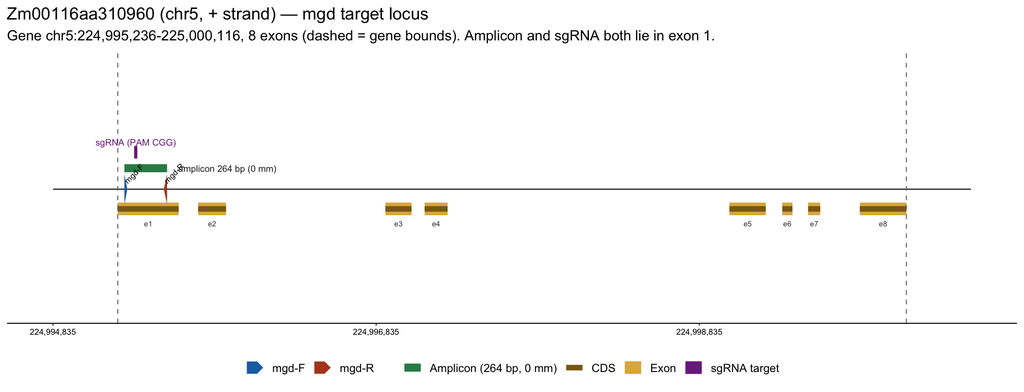

```r
p1 <- gggenomes(seqs = seqs, genes = prim_df,
                feats = list(amplicon = amp_df, exons = exon_df, cds = cds_df, guide = gd_df)) +
  geom_seq() +
  geom_feat(data = feats(exons), aes(y = y-0.16, yend = y-0.16, color = feat_type),
            position = "identity", linewidth = 5, alpha = 0.85) +
  geom_feat(data = feats(cds), aes(y = y-0.16, yend = y-0.16, color = feat_type),
            position = "identity", linewidth = 2.2) +
  geom_text(data = exon_df, aes(x = (start+end)/2, y = 1-0.28, label = name),
            size = 2.2, color = "grey25", inherit.aes = FALSE) +
  geom_feat(data = feats(amplicon), aes(y = y+0.17, yend = y+0.17, color = feat_type),
            position = "identity", linewidth = 3.2) +
  geom_feat(data = feats(guide), aes(y = y+0.30, yend = y+0.30, color = feat_type),
            position = "identity", linewidth = 5) +
  geom_text(data = amp_df, aes(x = end + 70, y = 1.17, label = name), hjust = 0, size = 2.7,
            color = "grey15", inherit.aes = FALSE) +
  geom_text(data = gd_df, aes(x = (start + end)/2, y = 1.38, label = name), hjust = 0.5, size = 2.7,
            color = "#7B2D8B", inherit.aes = FALSE) +
  geom_gene(aes(fill = feat_type), color = NA, size = 9) +
  geom_gene_label(aes(label = name), size = 2.4, nudge_y = 0.06) +
  geom_vline(xintercept = c(loc(tg$start), loc(tg$end)), linetype = "dashed", color = "grey45", linewidth = 0.4) +
  scale_color_manual(name = NULL, values = PAL_C, labels = LAB_C) +
  scale_fill_manual(name = NULL, values = PAL_F, labels = LAB_F) +
  scale_x_continuous(labels = function(x) format(round(x + WS - 1), big.mark = ",")) +
  coord_cartesian(ylim = c(0.62, 1.42)) +
  labs(title = sprintf("%s (chr5, %s strand) — mgd target locus", TG, tg$strand),
       subtitle = sprintf("Gene %s:%s-%s, %d exons (dashed = gene bounds). Amplicon and sgRNA both lie in exon 1.",
                          tg$seqid, format(tg$start, big.mark = ","), format(tg$end, big.mark = ","), nrow(tg_ex)),
       x = "chr5 position (bp)") +
  theme(legend.position = "bottom", axis.text.y = element_blank(), axis.ticks.y = element_blank(),
        axis.title.y = element_blank(), panel.grid.minor = element_blank())
ggsave(file.path(RES, "map_target_locus.png"), p1, width = 12, height = 4.6, dpi = 150)
p1
```

### 3.2 Exon 1 zoom — primers, amplicon and sgRNA

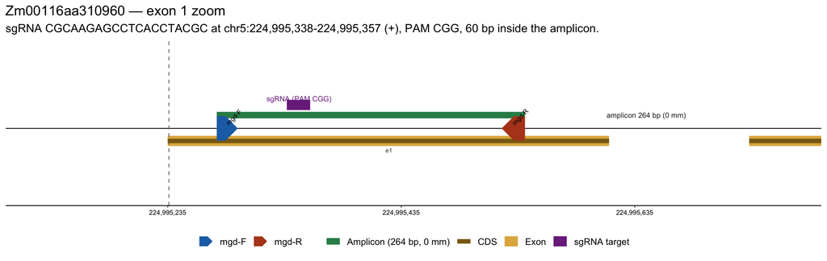

```r
p2 <- p1 + coord_cartesian(xlim = c(loc(tg_amp$from) - 150, loc(tg_ex$end[1]) + 150), ylim = c(0.72, 1.42)) +
  labs(title = sprintf("%s — exon 1 zoom", TG),
       subtitle = sprintf("sgRNA %s at chr5:%s-%s (+), PAM %s, %d bp inside the amplicon.",
                          GUIDE, format(tg_gd$start, big.mark = ","), format(tg_gd$end, big.mark = ","),
                          tg_gd$PAM, tg_gd$start - tg_amp$from))
ggsave(file.path(RES, "map_target_zoom.png"), p2, width = 12, height = 3.8, dpi = 150)
p2
```

### 3.3 The six credible amplicons side by side

Window = amplicon ± 150 bp, common scale. Minus-strand loci are flipped so `mgd-F` is always leftmost — every panel is in primer orientation, not genome orientation.

Six tracks per panel, bottom to top: **homology to the other five credible copies**, the **`TE_00012275` fragment** (labelled with the matched consensus interval), the **exon** of any overlapping gene, the **primer sites**, the **amplicon**, and — on the target panel only — the **sgRNA**. `mgd-F` sits inside a `TE_00012275` fragment in all six panels, which is why one pair of oligos picks up six loci.

The homology track exists because the RepeatMasker track alone *understates* the shared sequence. It is computed here, not annotated: each window is blastn’d against the other five (`-word_size 9`, no dust), overlapping HSPs on the query are merged, and blocks ≥40 bp are drawn. The two tracks disagree in an informative way — `mgd-R` overlaps no annotated repeat at any locus, yet at the target it falls **inside** a homology block, because the target’s `TE_00012275` call stops at chr5:224,995,320 while the sequence it shares with the repeat family runs on to ~224,995,580. The five off-target windows are homologous to each other across their **entire** 500 bp span, so the ~200 bp product is a small window onto a much larger shared element; the target shares only two blocks with them, one containing each primer site.

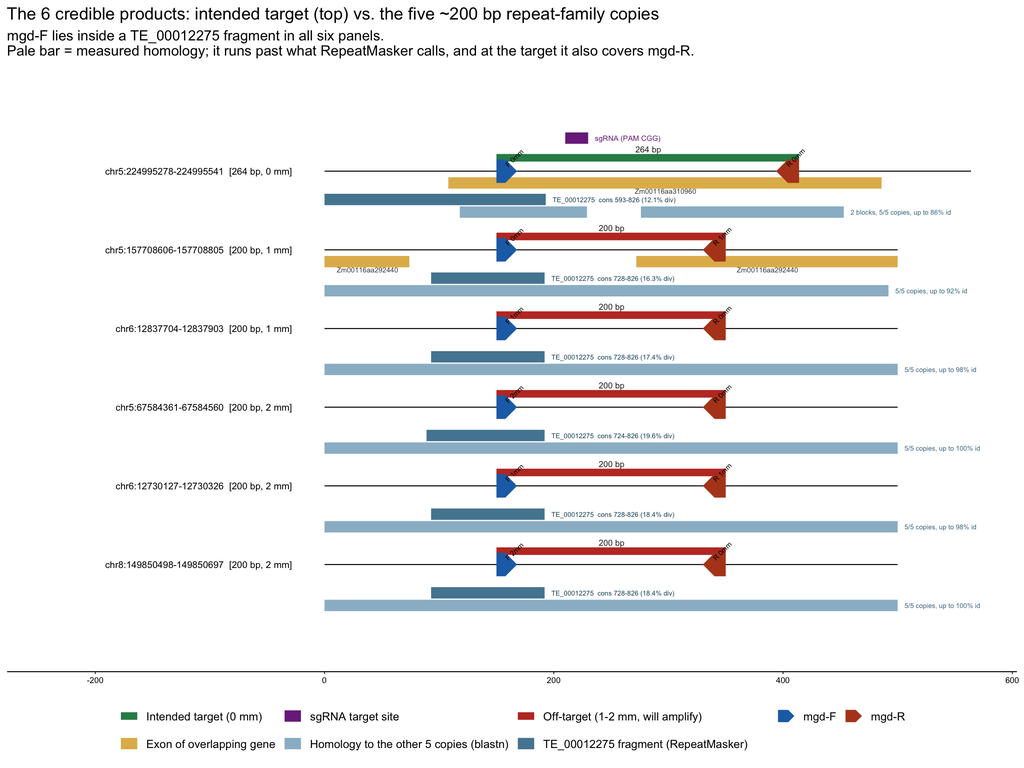

```r
PADP <- 150L
pan <- amp_ov %>% filter(gaps == 0) %>% arrange(mism, amp_bp) %>%
  mutate(win_start = from - PADP, win_end = to + PADP,
         panel = sprintf("%s  [%d bp, %d mm]", locus, amp_bp, mism)) %>%
  mutate(panel = factor(panel, levels = rev(panel)))
tl <- function(g, i) if (pan$strand[i] == "+") as.integer(g - pan$win_start[i] + 1L) else as.integer(pan$win_end[i] - g + 1L)
seg <- function(a, b, i) sort(c(tl(a, i), tl(b, i)))

pseqs <- pan %>% transmute(seq_id = as.character(panel), length = win_end - win_start + 1L)
pamp  <- bind_rows(lapply(seq_len(nrow(pan)), function(i) { a <- seg(pan$from[i], pan$to[i], i)
  tibble(seq_id = as.character(pan$panel[i]), start = a[1], end = a[2],
         feat_type = if (pan$mism[i] == 0) "amplicon" else "off_target",
         name = sprintf("%d bp", pan$amp_bp[i])) }))
pprim <- bind_rows(lapply(seq_len(nrow(pan)), function(i) {
  f <- seg(pan$F_start[i], pan$F_end[i], i); r <- seg(pan$R_start[i], pan$R_end[i], i)
  tibble(seq_id = as.character(pan$panel[i]), start = c(f[1], r[2]), end = c(f[2], r[1]),
         feat_type = c("forward_primer","reverse_primer"),
         name = sprintf(c("F %dmm","R %dmm"), c(pan$F_mm[i], pan$R_mm[i]))) }))
pex <- bind_rows(lapply(seq_len(nrow(pan)), function(i) {
  ex <- gm %>% filter(type == "exon", seqid == pan$chr[i], end >= pan$win_start[i], start <= pan$win_end[i])
  ex2 <- read_tsv(I(sh(sprintf("awk -F'\\t' 'NF==9 && $3==\"exon\" && $1==\"%s\" && $5>=%d && $4<=%d' %s",
                               pan$chr[i], pan$win_start[i], pan$win_end[i], shQuote(GFF)))),
                  col_names = gff_cols, show_col_types = FALSE)
  if (!nrow(ex2)) return(NULL)
  bind_rows(lapply(seq_len(nrow(ex2)), function(k) { s <- seg(max(ex2$start[k], pan$win_start[i]),
                                                             min(ex2$end[k], pan$win_end[i]), i)
    tibble(seq_id = as.character(pan$panel[i]), start = s[1], end = s[2], feat_type = "Exon",
           name = sub("_T001.*", "", sub(".*Parent=", "", ex2$attr[k]))) })) }))
# RepeatMasker track: type is always 'similarity', the family name is in the attribute column as
# Target "Motif:<name>" <consensus from> <consensus to>. Grep the motif, keep the consensus interval.
TE_MOTIF <- "TE_00012275"
te_win <- function(chr, s, e, motif) read_tsv(I(sh(sprintf(
  "awk -F'\\t' -v c=%s -v s=%d -v e=%d 'NF==9 && $1==c && $5>=s && $4<=e && $9 ~ /Motif:%s\"/' %s",
  shQuote(chr), s, e, motif, shQuote(TEGFF)))), col_names = gff_cols, show_col_types = FALSE)

pte <- bind_rows(lapply(seq_len(nrow(pan)), function(i) {
  te <- te_win(pan$chr[i], pan$win_start[i], pan$win_end[i], TE_MOTIF)
  if (!nrow(te)) return(NULL)
  bind_rows(lapply(seq_len(nrow(te)), function(k) {
    s <- seg(max(te$start[k], pan$win_start[i]), min(te$end[k], pan$win_end[i]), i)
    cons <- str_match(te$attr[k], 'Motif:[^"]*"\\s+(\\d+)\\s+(\\d+)')
    tibble(seq_id = as.character(pan$panel[i]), start = s[1], end = s[2], feat_type = "TE",
           name = sprintf("%s  cons %s-%s (%s%% div)", TE_MOTIF, cons[2], cons[3],
                          trimws(te$score[k]))) })) }))
# The sgRNA is drawn wherever a guide site falls inside a panel window — only the on-target does,
# so this puts it on the 264 bp Zm00116aa310960 panel without hardcoding which panel that is.
pgd <- bind_rows(lapply(seq_len(nrow(pan)), function(i) {
  g <- gsites %>% filter(chr == pan$chr[i], end >= pan$win_start[i], start <= pan$win_end[i])
  if (!nrow(g)) return(NULL)
  bind_rows(lapply(seq_len(nrow(g)), function(k) {
    s <- seg(g$start[k], g$end[k], i)
    tibble(seq_id = as.character(pan$panel[i]), start = s[1], end = s[2], feat_type = "guide",
           name = sprintf("sgRNA (PAM %s)", g$PAM[k])) })) }))
# Homology track: what the six windows actually share, independent of RepeatMasker. Windows are
# written in PANEL orientation (minus-strand loci reverse-complemented), so blastn query
# coordinates are already panel coordinates and need no seg()/tl() translation.
win_fa <- file.path(WORK, "panel_windows.fa")
writeLines(unlist(lapply(seq_len(nrow(pan)), function(i)
  c(sprintf(">%s", pan$locus[i]),
    grab(pan$chr[i], pan$win_start[i], pan$win_end[i], pan$strand[i] == "-")))), win_fa)
hom <- read_tsv(I(sh(sprintf(
  paste("blastn -task blastn -query %s -subject %s",
        "-outfmt \"6 qseqid sseqid pident qstart qend\" -evalue 1e-5 -word_size 9 -dust no"),
  shQuote(win_fa), shQuote(win_fa)))),
  col_names = c("q","s","pident","qstart","qend"), show_col_types = FALSE) %>% filter(q != s)

merge_iv <- function(d) {                      # merge overlapping/abutting HSPs on the query
  d <- d %>% arrange(qstart); out <- list(); cur <- NULL
  for (k in seq_len(nrow(d))) {
    if (is.null(cur)) cur <- list(s = d$qstart[k], e = d$qend[k], p = d$pident[k], subj = d$s[k])
    else if (d$qstart[k] <= cur$e + 1L) {
      cur$e <- max(cur$e, d$qend[k]); cur$p <- c(cur$p, d$pident[k]); cur$subj <- c(cur$subj, d$s[k])
    } else { out[[length(out)+1L]] <- cur
             cur <- list(s = d$qstart[k], e = d$qend[k], p = d$pident[k], subj = d$s[k]) }
  }
  if (!is.null(cur)) out[[length(out)+1L]] <- cur
  bind_rows(lapply(out, function(z) tibble(start = z$s, end = z$e,
    n_copies = n_distinct(z$subj), pmax = max(z$p))))
}
MIN_HOM <- 40L   # guard only: shortest HSP here is 111 bp, so nothing is dropped unless PADP widens
phom <- bind_rows(lapply(seq_len(nrow(pan)), function(i) {
  h <- hom %>% filter(q == pan$locus[i]); if (!nrow(h)) return(NULL)
  m <- merge_iv(h) %>% filter(end - start + 1L >= MIN_HOM); if (!nrow(m)) return(NULL)
  m %>% transmute(seq_id = as.character(pan$panel[i]), start, end, feat_type = "homology",
                  n_copies, pmax, name = sprintf("%d/%d copies, up to %.0f%% id",
                                                 n_copies, nrow(pan) - 1L, pmax)) }))
# One label per panel, past the rightmost block — a per-block label would be overdrawn by the next
# block on the target, which is the only panel with more than one.
phom_lab <- if (is.null(phom) || !nrow(phom))
  tibble(seq_id = character(), x = integer(), label = character()) else
  phom %>% group_by(seq_id) %>%
    summarise(x = max(end), nblk = n(), copies = max(n_copies), best = max(pmax), .groups = "drop") %>%
    mutate(label = ifelse(nblk == 1L,
      sprintf("%d/%d copies, up to %.0f%% id", copies, nrow(pan) - 1L, best),
      sprintf("%d blocks, %d/%d copies, up to %.0f%% id", nblk, copies, nrow(pan) - 1L, best)))
# gggenomes only registers tracks from a plain list(); a conditional c(list(), if(..) list()) does not.
empty_feat <- tibble(seq_id = character(), start = integer(), end = integer(),
                     feat_type = character(), name = character())
if (is.null(pex)  || !nrow(pex))  pex  <- empty_feat
if (is.null(pte)  || !nrow(pte))  pte  <- empty_feat
if (is.null(pgd)  || !nrow(pgd))  pgd  <- empty_feat
if (is.null(phom) || !nrow(phom)) phom <- empty_feat
# Text layers need their own y, one row per bin, else every label collapses onto a single y.
gg <- gggenomes(seqs = pseqs, genes = pprim,
                feats = list(amplicons = pamp, exons = pex, tes = pte, guide = pgd, homology = phom))
ymap <- pull_seqs(gg$data) %>% ungroup() %>% select(seq_id, y)

p3 <- gg + geom_seq() + geom_bin_label(size = 2.8, expand_left = 0.42) +
  geom_feat(data = feats(homology), aes(y = y-0.52, yend = y-0.52, color = feat_type),
            position = "identity", linewidth = 4.5, alpha = 0.8) +
  geom_text(data = phom_lab %>% left_join(ymap, by = "seq_id"), aes(x = x + 6, y = y-0.52, label = label),
            hjust = 0, size = 2.0, color = "#4E7A93", inherit.aes = FALSE) +
  geom_feat(data = feats(tes), aes(y = y-0.36, yend = y-0.36, color = feat_type),
            position = "identity", linewidth = 4.5, alpha = 0.85) +
  geom_text(data = pte %>% left_join(ymap, by = "seq_id"), aes(x = end + 6, y = y-0.36, label = name),
            hjust = 0, size = 2.0, color = "#1F5468", inherit.aes = FALSE) +
  geom_feat(data = feats(exons), aes(y = y-0.15, yend = y-0.15, color = feat_type),
            position = "identity", linewidth = 4.5, alpha = 0.8) +
  geom_text(data = pex %>% left_join(ymap, by = "seq_id"), aes(x = (start+end)/2, y = y-0.25, label = name),
            size = 2.1, color = "grey30", inherit.aes = FALSE) +
  geom_feat(data = feats(amplicons), aes(y = y+0.17, yend = y+0.17, color = feat_type),
            position = "identity", linewidth = 3) +
  geom_text(data = pamp %>% left_join(ymap, by = "seq_id"), aes(x = (start+end)/2, y = y+0.28, label = name),
            size = 2.5, color = "grey15", inherit.aes = FALSE) +
  geom_feat(data = feats(guide), aes(y = y+0.42, yend = y+0.42, color = feat_type),
            position = "identity", linewidth = 4.5) +
  geom_text(data = pgd %>% left_join(ymap, by = "seq_id"), aes(x = end + 6, y = y+0.42, label = name),
            hjust = 0, size = 2.2, color = "#7B2D8B", inherit.aes = FALSE) +
  geom_gene(aes(fill = feat_type), color = NA, size = 7) +
  geom_gene_label(aes(label = name), size = 2.1, nudge_y = 0.07) +
  scale_color_manual(name = NULL,
    values = c("homology" = "#7FA8C0", "TE" = "#2C6E8F", "Exon" = "#DAA520",
               "amplicon" = "#2E8B57", "off_target" = "#C0392B", "guide" = "#7B2D8B"),
    labels = c("homology" = "Homology to the other 5 copies (blastn)",
               "TE" = sprintf("%s fragment (RepeatMasker)", TE_MOTIF),
               "Exon" = "Exon of overlapping gene", "amplicon" = "Intended target (0 mm)",
               "off_target" = "Off-target (1-2 mm, will amplify)", "guide" = "sgRNA target site")) +
  scale_fill_manual(name = NULL, values = PAL_F, labels = LAB_F) +
  coord_cartesian(ylim = c(0.40, nrow(pan) + 0.58)) +
  labs(title = "The 6 credible products: intended target (top) vs. the five ~200 bp repeat-family copies",
       subtitle = sprintf(paste0("mgd-F lies inside a %s fragment in all six panels.\n",
                                 "Pale bar = measured homology; it runs past what RepeatMasker ",
                                 "calls, and at the target it also covers mgd-R."), TE_MOTIF),
       x = "position within window (bp)") +
  theme(legend.position = "bottom", axis.text.y = element_blank(), axis.ticks.y = element_blank(),
        axis.title.y = element_blank(), panel.grid.minor = element_blank())
ggsave(file.path(RES, "map_credible_loci.png"), p3, width = 12, height = 9, dpi = 150)
p3
```

## 4. New primers designed around the guide (Primer3)

```r
E1S <- min(tg_ex$start); GS <- tg_gd$start; GE <- tg_gd$end
WS2 <- E1S - 500L; WE2 <- GE + 450L
tmpl <- grab(tg$seqid, WS2, WE2)
gl   <- GS - WS2                                  # 0-based local guide start
stopifnot(substr(tmpl, gl + 1, gl + 20) == GUIDE, E1S - WS2 == 500)
writeLines(tmpl, file.path(WORK, "design_window.txt"))

p3in <- file.path(WORK, "p3_guide.txt"); p3out <- file.path(WORK, "p3_guide_out.txt")
writeLines(c("SEQUENCE_ID=mgd_guide", paste0("SEQUENCE_TEMPLATE=", tmpl),
  sprintf("SEQUENCE_TARGET=%d,20", gl), sprintf("SEQUENCE_EXCLUDED_REGION=%d,120", gl - 50L),
  "PRIMER_TASK=generic","PRIMER_FIRST_BASE_INDEX=0",
  "PRIMER_PICK_LEFT_PRIMER=1","PRIMER_PICK_RIGHT_PRIMER=1","PRIMER_PICK_INTERNAL_OLIGO=0",
  "PRIMER_PRODUCT_SIZE_RANGE=150-500",
  "PRIMER_MIN_SIZE=19","PRIMER_OPT_SIZE=21","PRIMER_MAX_SIZE=24",
  "PRIMER_MIN_TM=58.0","PRIMER_OPT_TM=60.0","PRIMER_MAX_TM=62.0","PRIMER_PAIR_MAX_DIFF_TM=2.0",
  "PRIMER_MIN_GC=40.0","PRIMER_OPT_GC_PERCENT=50.0","PRIMER_MAX_GC=60.0",
  "PRIMER_GC_CLAMP=1","PRIMER_MAX_POLY_X=4","PRIMER_MAX_NS_ACCEPTED=0",
  "PRIMER_THERMODYNAMIC_OLIGO_ALIGNMENT=0","PRIMER_THERMODYNAMIC_TEMPLATE_ALIGNMENT=0",
  "PRIMER_EXPLAIN_FLAG=1","PRIMER_NUM_RETURN=20","="), p3in)
sh(sprintf("primer3_core %s > %s", shQuote(p3in), shQuote(p3out)))
```

```
character(0)
```

```r
L <- readLines(p3out); L <- L[grepl("=", L, fixed = TRUE) & L != "="]
kv <- strsplit(L, "=", fixed = TRUE)
d  <- setNames(vapply(kv, function(x) paste(x[-1], collapse = "="), ""), vapply(kv, `[`, "", 1))
np <- as.integer(d[["PRIMER_PAIR_NUM_RETURNED"]])
pairs <- bind_rows(lapply(0:(np-1), function(i) {
  lp <- as.integer(strsplit(d[[sprintf("PRIMER_LEFT_%d", i)]], ",")[[1]])
  rp <- as.integer(strsplit(d[[sprintf("PRIMER_RIGHT_%d", i)]], ",")[[1]])
  f5 <- WS2 + lp[1]; r5 <- WS2 + rp[1]
  tibble(rank = i, penalty = round(as.numeric(d[[sprintf("PRIMER_PAIR_%d_PENALTY", i)]]), 3),
    prod = as.integer(d[[sprintf("PRIMER_PAIR_%d_PRODUCT_SIZE", i)]]),
    F_seq = d[[sprintf("PRIMER_LEFT_%d_SEQUENCE", i)]], R_seq = d[[sprintf("PRIMER_RIGHT_%d_SEQUENCE", i)]],
    F_len = lp[2], R_len = rp[2],
    F_tm = round(as.numeric(d[[sprintf("PRIMER_LEFT_%d_TM", i)]]), 2),
    R_tm = round(as.numeric(d[[sprintf("PRIMER_RIGHT_%d_TM", i)]]), 2),
    F_gc = round(as.numeric(d[[sprintf("PRIMER_LEFT_%d_GC_PERCENT", i)]]), 1),
    R_gc = round(as.numeric(d[[sprintf("PRIMER_RIGHT_%d_GC_PERCENT", i)]]), 1),
    F_start = f5, F_end = f5 + lp[2] - 1L, R_end = r5 - rp[2] + 1L, R_start = r5,
    gap5 = GS - (f5 + lp[2] - 1L) - 1L, gap3 = (r5 - rp[2] + 1L) - GE - 1L)
}))
# Re-check every constraint independently of Primer3's own filtering.
chk <- pairs %>% transmute(rank,
  len = F_len >= 19 & F_len <= 24 & R_len >= 19 & R_len <= 24,
  tm  = F_tm >= 58 & F_tm <= 62 & R_tm >= 58 & R_tm <= 62,
  prod_ok = prod >= 150 & prod <= 500,
  clearance = gap5 >= 50 & gap3 >= 50,
  clamp = grepl("[GC]$", F_seq) & grepl("[GC]$", R_seq))
cat(sprintf("Primer3 returned %d pairs; all constraints independently satisfied: %s\n",
            np, all(as.matrix(chk[,-1]))))
```

```
Primer3 returned 20 pairs; all constraints independently satisfied: TRUE
```

```r
oligos <- unique(c(pairs$F_seq, pairs$R_seq))
ofa <- file.path(WORK, "cand_oligos.fa"); writeLines(paste0(">o", seq_along(oligos), "\n", oligos), ofa)
bl <- read_tsv(I(sh(sprintf(
  "blastn -task blastn-short -query %s -db %s -evalue 1000 -max_target_seqs 100000 -num_threads 6 -outfmt %s",
  shQuote(ofa), shQuote(DB), shQuote("6 qseqid length mismatch")))),
  col_names = c("q","len","mm"), show_col_types = FALSE) %>%
  mutate(oligo = oligos[as.integer(sub("^o", "", q))])
cnt <- bl %>% filter(len == nchar(oligo), mm == 0) %>% count(oligo, name = "perfect_sites")
knitr::kable(cnt %>% arrange(desc(perfect_sites)),
             caption = "Perfect full-length genomic sites per candidate oligo. The two 3-copy oligos are repeat-motif derived and are rejected.")
```

Perfect full-length genomic sites per candidate oligo. The two 3-copy oligos are repeat-motif derived and are rejected.

| oligo | perfect_sites |
| --- | --- |
| CGCTCATGAGGATGAGGACG | 3 |
| TCGCTCATGAGGATGAGGAC | 3 |
| AGAACATCCGGCGCTTTCAC | 1 |
| ATCCCCAATTTTAAACGCCCC | 1 |
| CAGAACATCCGGCGCTTTC | 1 |
| CCAGAACATCCGGCGCTTTC | 1 |
| CCGATCCCCAATTTTAAACGCC | 1 |
| CGATCCCCAATTTTAAACGCCC | 1 |
| CTTCTCTCTCCTGCCCACTC | 1 |
| GAACATCCGGCGCTTTCAC | 1 |
| GACGTTCTTAGCGCGGTTG | 1 |
| GATCCCCAATTTTAAACGCCCC | 1 |
| GGACAGCACGAGTGATGAATG | 1 |
| TACTCGTCGCCAAACTCGATG | 1 |
| TCCGATCCCCAATTTTAAACGC | 1 |
| TTCTCTCTCCTGCCCACTCG | 1 |

```r
elig <- pairs %>%
  left_join(cnt %>% dplyr::rename(F_seq = oligo, F_sites = perfect_sites), by = "F_seq") %>%
  left_join(cnt %>% dplyr::rename(R_seq = oligo, R_sites = perfect_sites), by = "R_seq") %>%
  mutate(across(c(F_sites, R_sites), ~replace_na(., 0L))) %>%
  filter(F_sites == 1, R_sites == 1) %>% arrange(penalty)
best <- elig[0, ]                                     # greedy: lowest penalty, distinct reverse primer
for (i in seq_len(nrow(elig))) if (!(elig$R_seq[i] %in% best$R_seq)) {
  best <- bind_rows(best, elig[i, ]); if (nrow(best) == 3) break }
best <- best %>% mutate(name = paste0("mgdG-", row_number()))
cat(sprintf("%d/%d pairs have both primers single-copy.\n", nrow(elig), nrow(pairs)))
```

```
8/20 pairs have both primers single-copy.
```

```r
write_tsv(best, file.path(RES, "new_primers.tsv"))
```

```r
knitr::kable(best %>% transmute(name, `product bp` = prod, penalty,
  forward = F_seq, F_len, F_Tm = F_tm, `F_GC%` = F_gc,
  reverse = R_seq, R_len, R_Tm = R_tm, `R_GC%` = R_gc,
  `bp 5' of guide` = gap5, `bp 3' of guide` = gap3),
  caption = "The best 3 pairs. Five unique oligos total (mgdG-1 and mgdG-2 share the forward primer).")
```

The best 3 pairs. Five unique oligos total (mgdG-1 and mgdG-2 share the forward primer).

| name | product bp | penalty | forward | F_len | F_Tm | F_GC% | reverse | R_len | R_Tm | R_GC% | bp 5’ of guide | bp 3’ of guide |
| --- | --- | --- | --- | --- | --- | --- | --- | --- | --- | --- | --- | --- |
| mgdG-1 | 426 | 2.602 | GAACATCCGGCGCTTTCAC | 19 | 59.87 | 57.9 | TACTCGTCGCCAAACTCGATG | 21 | 60.47 | 52.4 | 135 | 231 |
| mgdG-2 | 485 | 2.797 | GAACATCCGGCGCTTTCAC | 19 | 59.87 | 57.9 | GGACAGCACGAGTGATGAATG | 21 | 59.34 | 52.4 | 135 | 290 |
| mgdG-3 | 439 | 3.250 | ATCCCCAATTTTAAACGCCCC | 21 | 59.16 | 47.6 | GACGTTCTTAGCGCGGTTG | 19 | 59.58 | 57.9 | 235 | 144 |

### Specificity of the new pairs — e-PCR

```r
sts2 <- file.path(WORK, "epcr_final.sts")
writeLines(sprintf("%s\t%s\t%s\t150-600", best$name, best$F_seq, best$R_seq), sts2)
out2 <- file.path(RES, "epcr_final.txt")
sh(sprintf("e-PCR -n 3 -g 1 -m 50 -w 7 -t 3 -a f -o %s %s %s", shQuote(out2), shQuote(sts2), shQuote(GENOFA)))
```

```
character(0)
```

```r
ep2 <- read_tsv(out2, comment = "#", show_col_types = FALSE,
                col_names = c("seq","sts","strand","from","to","size","mism","gaps","x"))
knitr::kable(ep2 %>% transmute(pair = sts, chr = seq, strand, from, to = to + 1L,
                               size_bp = as.integer(str_replace(size, "/.*", "")) + 1L,
                               mismatches = mism, gaps),
  caption = sprintf("Genome-wide e-PCR (3 mismatches + 1 gap per primer): %s.",
    ifelse(all(table(ep2$sts) == 1) && all(ep2$mism == 0),
           "every pair gives exactly ONE product, at the target, with 0 mismatches",
           "CHECK — more than one product")))
```

Genome-wide e-PCR (3 mismatches + 1 gap per primer): every pair gives exactly ONE product, at the target, with 0 mismatches.

| pair | chr | strand | from | to | size_bp | mismatches | gaps |
| --- | --- | --- | --- | --- | --- | --- | --- |
| mgdG-1 | chr5 | + | 224995184 | 224995609 | 426 | 0 | 0 |
| mgdG-2 | chr5 | + | 224995184 | 224995668 | 485 | 0 | 0 |
| mgdG-3 | chr5 | + | 224995082 | 224995520 | 439 | 0 | 0 |

All three pairs are **single-product, zero-mismatch** genome-wide — a clean result compared with the original pair’s six products (§1).

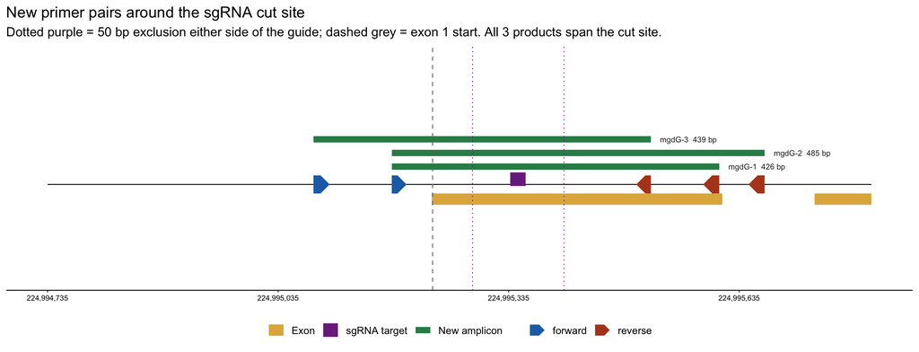

```r
nb <- best %>% mutate(y_off = 0.17 + 0.13 * (row_number() - 1))
nseq <- tibble(seq_id = "locus", length = WE2 - WS2 + 1L)
l2 <- function(g) as.integer(g - WS2 + 1L)
nex <- gm %>% filter(type == "exon", end >= WS2, start <= WE2) %>%
  transmute(seq_id = "locus", start = l2(pmax(start, WS2)), end = l2(pmin(end, WE2)), feat_type = "Exon")
ngd <- tibble(seq_id = "locus", start = l2(GS), end = l2(GE), feat_type = "guide")
namp <- nb %>% transmute(seq_id = "locus", start = l2(F_start), end = l2(R_start),
                         feat_type = "new_amplicon", name = sprintf("%s  %d bp", name, prod), y_off)
nprim <- bind_rows(lapply(seq_len(nrow(nb)), function(i) tibble(seq_id = "locus",
  start = c(l2(nb$F_start[i]), l2(nb$R_start[i])), end = c(l2(nb$F_end[i]), l2(nb$R_end[i])),
  feat_type = c("forward_primer","reverse_primer"))))

p4 <- gggenomes(seqs = nseq, genes = nprim, feats = list(amps = namp, exons = nex, guide = ngd)) +
  geom_seq() +
  geom_feat(data = feats(exons), aes(y = y-0.14, yend = y-0.14, color = feat_type),
            position = "identity", linewidth = 5, alpha = 0.85) +
  geom_feat(data = feats(guide), aes(y = y+0.05, yend = y+0.05, color = feat_type),
            position = "identity", linewidth = 6) +
  geom_feat(data = feats(amps), aes(y = y+y_off, yend = y+y_off, color = feat_type),
            position = "identity", linewidth = 2.8) +
  geom_text(data = namp, aes(x = end + 12, y = 1 + y_off, label = name), hjust = 0,
            size = 2.6, color = "grey15", inherit.aes = FALSE) +
  geom_gene(aes(fill = feat_type), color = NA, size = 6) +
  geom_vline(xintercept = c(l2(GS - 50), l2(GE + 50)), linetype = "dotted", color = "#7B2D8B", linewidth = 0.4) +
  geom_vline(xintercept = l2(E1S), linetype = "dashed", color = "grey45", linewidth = 0.4) +
  scale_color_manual(name = NULL,
    values = c("Exon" = "#DAA520", "guide" = "#7B2D8B", "new_amplicon" = "#2E8B57"),
    labels = c("Exon" = "Exon", "guide" = "sgRNA target", "new_amplicon" = "New amplicon")) +
  scale_fill_manual(name = NULL, values = PAL_F, labels = c("forward_primer" = "forward", "reverse_primer" = "reverse")) +
  scale_x_continuous(labels = function(x) format(round(x + WS2 - 1), big.mark = ",")) +
  coord_cartesian(ylim = c(0.7, 1.62)) +
  labs(title = "New primer pairs around the sgRNA cut site",
       subtitle = "Dotted purple = 50 bp exclusion either side of the guide; dashed grey = exon 1 start. All 3 products span the cut site.",
       x = "chr5 position (bp)") +
  theme(legend.position = "bottom", axis.text.y = element_blank(), axis.ticks.y = element_blank(),
        axis.title.y = element_blank(), panel.grid.minor = element_blank())
ggsave(file.path(RES, "map_new_primers.png"), p4, width = 12, height = 4.6, dpi = 150)
p4
```

## Bottom line

[output not shown]

The two bands are 64 bp apart and resolvable on a 2 % gel, but the ~200 bp band competes for primer and polymerase and cannot be used for dosage or presence/absence calls. **Moving the reverse primer into intron 1** (`chr5:224,995,614-224,995,733`) breaks the 200 bp repeat architecture and makes the product intron-spanning; re-running this document is the check.

The **sgRNA itself is well placed**: unique as a perfect match, inside exon 1 of the target, with its only two near-matches (1 mismatch at position 19, PAM-proximal) in intergenic space.

*Caveats.* e-PCR and BLAST are string-matching scans, not thermodynamic or cleavage models — a 3′-intact ≤2-mismatch primer site is *expected* to amplify and a 19/20 + NGG site is a *candidate* cut site; both need empirical confirmation. `Zm00116aa310960` is identified as an MGDG synthase from its protein sequence, not from the GFF3, which carries no functional annotation.

## References

- LH244 reference and annotation: **Zm-LH244-REFERENCE-CAU-1.0**, `Zm00116aa.1`, MaizeGDB. https://download.maizegdb.org/Zm-LH244-REFERENCE-CAU-1.0/
- **e-PCR**: Schuler GD (1997) Sequence mapping by electronic PCR. *Genome Res* 7:541-550.
- **BLAST+**: Camacho C *et al.* (2009) *BMC Bioinformatics* 10:421. (`blastn-short` for queries < 50 nt.)
- **bedtools**: Quinlan AR & Hall IM (2010) *Bioinformatics* 26:841-842.
- **gggenomes**: Hackl T *et al.* — https://thackl.github.io/gggenomes/